# Risk Factor Analysis

## Outcome Variable

**Outcome Variable:** whz

## Predictor Variables

**Intervention Variable:** feducyrs

**Adjustment Set:**

- arm
- W_mage
- meducyrs
- W_mhtcm
- W_gagebrth
- W_birthwt
- W_birthlen
- single
- delta_W_mage
- delta_meducyrs
- delta_W_mhtcm
- delta_W_gagebrth
- delta_W_birthwt
- delta_W_birthlen
- delta_single

## Stratifying Variables

The analysis was stratified on these variable(s):

- agecat
- studyid
- country

## Data Summary

| agecat | studyid | country | feducyrs | n_cell | n |
| --- | --- | --- | --- | --- | --- |
| Birth | ki0047075b-MAL-ED | BANGLADESH | High | 49 | 134 |
| Birth | ki0047075b-MAL-ED | BANGLADESH | Low | 35 | 134 |
| Birth | ki0047075b-MAL-ED | BANGLADESH | Medium | 50 | 134 |
| Birth | ki0047075b-MAL-ED | INDIA | High | 38 | 121 |
| Birth | ki0047075b-MAL-ED | INDIA | Low | 48 | 121 |
| Birth | ki0047075b-MAL-ED | INDIA | Medium | 35 | 121 |
| Birth | ki0047075b-MAL-ED | NEPAL | High | 27 | 64 |
| Birth | ki0047075b-MAL-ED | NEPAL | Low | 18 | 64 |
| Birth | ki0047075b-MAL-ED | NEPAL | Medium | 19 | 64 |
| Birth | ki0047075b-MAL-ED | PERU | High | 112 | 230 |
| Birth | ki0047075b-MAL-ED | PERU | Low | 63 | 230 |
| Birth | ki0047075b-MAL-ED | PERU | Medium | 55 | 230 |
| Birth | ki0047075b-MAL-ED | SOUTH AFRICA | High | 35 | 91 |
| Birth | ki0047075b-MAL-ED | SOUTH AFRICA | Low | 30 | 91 |
| Birth | ki0047075b-MAL-ED | SOUTH AFRICA | Medium | 26 | 91 |
| Birth | ki0047075b-MAL-ED | TANZANIA, UNITED REPUBLIC OF | High | 63 | 96 |
| Birth | ki0047075b-MAL-ED | TANZANIA, UNITED REPUBLIC OF | Low | 27 | 96 |
| Birth | ki0047075b-MAL-ED | TANZANIA, UNITED REPUBLIC OF | Medium | 6 | 96 |
| Birth | ki1000304b-SAS-CompFeed | INDIA | High | 33 | 166 |
| Birth | ki1000304b-SAS-CompFeed | INDIA | Low | 68 | 166 |
| Birth | ki1000304b-SAS-CompFeed | INDIA | Medium | 65 | 166 |
| Birth | ki1017093c-NIH-Crypto | BANGLADESH | High | 7 | 23 |
| Birth | ki1017093c-NIH-Crypto | BANGLADESH | Low | 11 | 23 |
| Birth | ki1017093c-NIH-Crypto | BANGLADESH | Medium | 5 | 23 |
| Birth | ki1119695-PROBIT | BELARUS | High | 2050 | 13359 |
| Birth | ki1119695-PROBIT | BELARUS | Low | 5294 | 13359 |
| Birth | ki1119695-PROBIT | BELARUS | Medium | 6015 | 13359 |
| Birth | ki1126311-ZVITAMBO | ZIMBABWE | High | 914 | 12572 |
| Birth | ki1126311-ZVITAMBO | ZIMBABWE | Low | 2090 | 12572 |
| Birth | ki1126311-ZVITAMBO | ZIMBABWE | Medium | 9568 | 12572 |

[output cut: 129 more lines]

The following strata were considered:

- agecat: 24 months, studyid: ki0047075b-MAL-ED, country: BANGLADESH
- agecat: 24 months, studyid: ki0047075b-MAL-ED, country: INDIA
- agecat: 24 months, studyid: ki0047075b-MAL-ED, country: NEPAL
- agecat: 24 months, studyid: ki0047075b-MAL-ED, country: PERU
- agecat: 24 months, studyid: ki0047075b-MAL-ED, country: SOUTH AFRICA
- agecat: 24 months, studyid: ki0047075b-MAL-ED, country: TANZANIA, UNITED REPUBLIC OF
- agecat: 24 months, studyid: ki1017093b-PROVIDE, country: BANGLADESH
- agecat: 24 months, studyid: ki1017093c-NIH-Crypto, country: BANGLADESH
- agecat: 24 months, studyid: ki1066203-TanzaniaChild2, country: TANZANIA, UNITED REPUBLIC OF
- agecat: 24 months, studyid: ki1113344-GMS-Nepal, country: NEPAL
- agecat: 24 months, studyid: ki1119695-PROBIT, country: BELARUS
- agecat: 24 months, studyid: ki1126311-ZVITAMBO, country: ZIMBABWE
- agecat: 24 months, studyid: ki1135781-COHORTS, country: GUATEMALA
- agecat: 24 months, studyid: ki1135781-COHORTS, country: INDIA
- agecat: 24 months, studyid: ki1135781-COHORTS, country: PHILIPPINES
- agecat: 24 months, studyid: ki1148112-LCNI-5, country: MALAWI
- agecat: 24 months, studyid: kiGH5241-JiVitA-3, country: BANGLADESH
- agecat: 24 months, studyid: kiGH5241-JiVitA-4, country: BANGLADESH
- agecat: 6 months, studyid: ki0047075b-MAL-ED, country: BANGLADESH
- agecat: 6 months, studyid: ki0047075b-MAL-ED, country: INDIA
- agecat: 6 months, studyid: ki0047075b-MAL-ED, country: NEPAL
- agecat: 6 months, studyid: ki0047075b-MAL-ED, country: PERU
- agecat: 6 months, studyid: ki0047075b-MAL-ED, country: SOUTH AFRICA
- agecat: 6 months, studyid: ki0047075b-MAL-ED, country: TANZANIA, UNITED REPUBLIC OF
- agecat: 6 months, studyid: ki1000304b-SAS-CompFeed, country: INDIA
- agecat: 6 months, studyid: ki1000304b-SAS-FoodSuppl, country: INDIA
- agecat: 6 months, studyid: ki1017093b-PROVIDE, country: BANGLADESH
- agecat: 6 months, studyid: ki1017093c-NIH-Crypto, country: BANGLADESH
- agecat: 6 months, studyid: ki1066203-TanzaniaChild2, country: TANZANIA, UNITED REPUBLIC OF
- agecat: 6 months, studyid: ki1113344-GMS-Nepal, country: NEPAL
- agecat: 6 months, studyid: ki1119695-PROBIT, country: BELARUS
- agecat: 6 months, studyid: ki1126311-ZVITAMBO, country: ZIMBABWE
- agecat: 6 months, studyid: ki1135781-COHORTS, country: GUATEMALA
- agecat: 6 months, studyid: ki1135781-COHORTS, country: INDIA
- agecat: 6 months, studyid: ki1135781-COHORTS, country: PHILIPPINES
- agecat: 6 months, studyid: ki1148112-LCNI-5, country: MALAWI
- agecat: 6 months, studyid: kiGH5241-JiVitA-3, country: BANGLADESH
- agecat: 6 months, studyid: kiGH5241-JiVitA-4, country: BANGLADESH
- agecat: Birth, studyid: ki0047075b-MAL-ED, country: BANGLADESH
- agecat: Birth, studyid: ki0047075b-MAL-ED, country: INDIA
- agecat: Birth, studyid: ki0047075b-MAL-ED, country: NEPAL
- agecat: Birth, studyid: ki0047075b-MAL-ED, country: PERU
- agecat: Birth, studyid: ki0047075b-MAL-ED, country: SOUTH AFRICA
- agecat: Birth, studyid: ki0047075b-MAL-ED, country: TANZANIA, UNITED REPUBLIC OF
- agecat: Birth, studyid: ki1000304b-SAS-CompFeed, country: INDIA
- agecat: Birth, studyid: ki1017093c-NIH-Crypto, country: BANGLADESH
- agecat: Birth, studyid: ki1119695-PROBIT, country: BELARUS
- agecat: Birth, studyid: ki1126311-ZVITAMBO, country: ZIMBABWE
- agecat: Birth, studyid: ki1135781-COHORTS, country: GUATEMALA
- agecat: Birth, studyid: ki1135781-COHORTS, country: INDIA
- agecat: Birth, studyid: ki1135781-COHORTS, country: PHILIPPINES
- agecat: Birth, studyid: kiGH5241-JiVitA-3, country: BANGLADESH
- agecat: Birth, studyid: kiGH5241-JiVitA-4, country: BANGLADESH

### Dropped Strata

Some strata were dropped due to rare outcomes:

- agecat: 24 months, studyid: ki1066203-TanzaniaChild2, country: TANZANIA, UNITED REPUBLIC OF

## Methods Detail

We’re interested in the causal parameters $E[Y_a]$ for all values of $a \in \mathcal{A}$. These parameters represent the mean outcome if, possibly contrary to fact, we intervened to set all units to have $A=a$. Under the randomization and positivity assumptions, these are identified by the statistical parameters $\psi_a=E_W[E_{Y|A,W}(Y|A=a,W)]$. In addition, we’re interested in the mean of $Y$, $E[Y]$ under no intervention (the observed mean). We will estimate these parameters by using SuperLearner to fit the relevant likelihood factors – $E_{Y|A,W}(Y|A=a,W)$ and $p(A=a|W)$, and then updating our likelihood fit using a joint TMLE.

For unadjusted analyses ($W=\{\}$), initial likelihoods were estimated using Lrnr_glm to estimate the simple $E(Y|A)$ and Lrnr_mean to estimate $p(A)$. For adjusted analyses, a small library containing Lrnr_glmnet, Lrnr_xgboost, and Lrnr_mean was used.

Having estimated these parameters, we will then use the delta method to estimate relative risks and attributable risks relative to a prespecified baseline level of $A$.

# Results Detail

## Results Plots

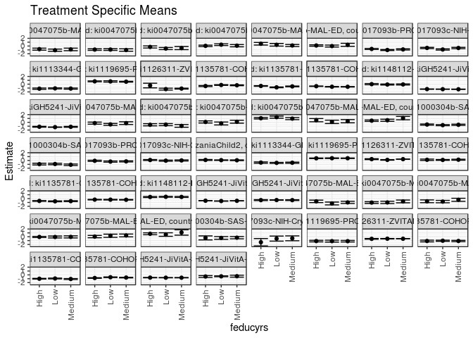

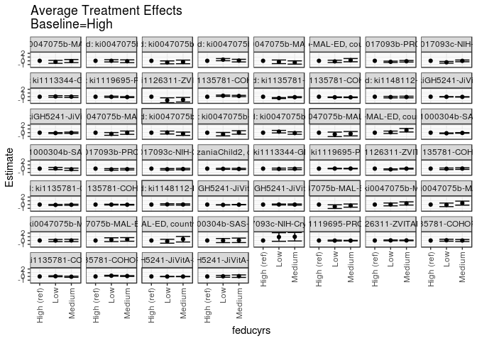

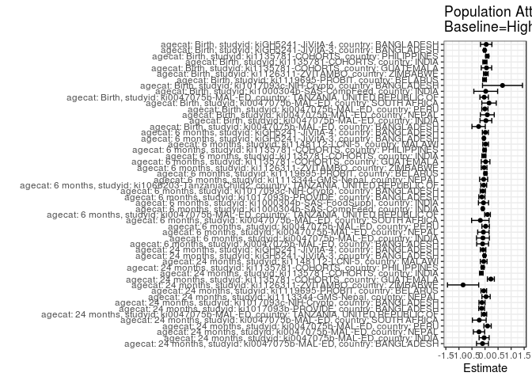

## Results Table

### Parameter: TSM

| agecat | studyid | country | intervention_level | baseline_level | estimate | ci_lower | ci_upper |
| --- | --- | --- | --- | --- | --- | --- | --- |
| Birth | ki0047075b-MAL-ED | BANGLADESH | High | NA | -0.7126231 | -1.0302812 | -0.3949650 |
| Birth | ki0047075b-MAL-ED | BANGLADESH | Low | NA | -1.2641949 | -1.6327389 | -0.8956508 |
| Birth | ki0047075b-MAL-ED | BANGLADESH | Medium | NA | -0.9856201 | -1.2673752 | -0.7038650 |
| Birth | ki0047075b-MAL-ED | INDIA | High | NA | -1.0285187 | -1.2595165 | -0.7975209 |
| Birth | ki0047075b-MAL-ED | INDIA | Low | NA | -0.9937015 | -1.2899189 | -0.6974841 |
| Birth | ki0047075b-MAL-ED | INDIA | Medium | NA | -0.7296453 | -1.0885391 | -0.3707515 |
| Birth | ki0047075b-MAL-ED | NEPAL | High | NA | -0.7004134 | -1.0622057 | -0.3386211 |
| Birth | ki0047075b-MAL-ED | NEPAL | Low | NA | -0.7722680 | -1.0850741 | -0.4594619 |
| Birth | ki0047075b-MAL-ED | NEPAL | Medium | NA | -0.3105785 | -0.7038062 | 0.0826493 |
| Birth | ki0047075b-MAL-ED | PERU | High | NA | -0.0558375 | -0.2035163 | 0.0918412 |
| Birth | ki0047075b-MAL-ED | PERU | Low | NA | -0.0646327 | -0.3137500 | 0.1844846 |
| Birth | ki0047075b-MAL-ED | PERU | Medium | NA | -0.0394361 | -0.3102821 | 0.2314099 |
| Birth | ki0047075b-MAL-ED | SOUTH AFRICA | High | NA | 0.0419627 | -0.2606773 | 0.3446028 |
| Birth | ki0047075b-MAL-ED | SOUTH AFRICA | Low | NA | 0.2577878 | -0.1525067 | 0.6680823 |
| Birth | ki0047075b-MAL-ED | SOUTH AFRICA | Medium | NA | 0.3345601 | -0.0314833 | 0.7006036 |
| Birth | ki0047075b-MAL-ED | TANZANIA, UNITED REPUBLIC OF | High | NA | 0.7669841 | 0.5145747 | 1.0193936 |
| Birth | ki0047075b-MAL-ED | TANZANIA, UNITED REPUBLIC OF | Low | NA | 0.5718519 | 0.1177775 | 1.0259262 |
| Birth | ki0047075b-MAL-ED | TANZANIA, UNITED REPUBLIC OF | Medium | NA | 1.1133333 | 0.4136753 | 1.8129914 |
| Birth | ki1000304b-SAS-CompFeed | INDIA | High | NA | -0.2967595 | -0.8133506 | 0.2198315 |
| Birth | ki1000304b-SAS-CompFeed | INDIA | Low | NA | -0.3082328 | -0.6588317 | 0.0423662 |
| Birth | ki1000304b-SAS-CompFeed | INDIA | Medium | NA | -0.2437014 | -0.5453082 | 0.0579054 |
| Birth | ki1017093c-NIH-Crypto | BANGLADESH | High | NA | -1.4200000 | -2.3657984 | -0.4742016 |
| Birth | ki1017093c-NIH-Crypto | BANGLADESH | Low | NA | -0.4800000 | -1.1381374 | 0.1781374 |
| Birth | ki1017093c-NIH-Crypto | BANGLADESH | Medium | NA | -0.4100000 | -1.0437501 | 0.2237501 |
| Birth | ki1119695-PROBIT | BELARUS | High | NA | -1.1240061 | -1.3257694 | -0.9222428 |
| Birth | ki1119695-PROBIT | BELARUS | Low | NA | -1.1408791 | -1.3895107 | -0.8922475 |
| Birth | ki1119695-PROBIT | BELARUS | Medium | NA | -1.1517092 | -1.3562570 | -0.9471614 |
| Birth | ki1126311-ZVITAMBO | ZIMBABWE | High | NA | -0.5402770 | -0.6321030 | -0.4484510 |
| Birth | ki1126311-ZVITAMBO | ZIMBABWE | Low | NA | -0.5092848 | -0.5750163 | -0.4435533 |
| Birth | ki1126311-ZVITAMBO | ZIMBABWE | Medium | NA | -0.5141028 | -0.5437414 | -0.4844643 |

[output cut: 126 more lines]

### Parameter: E(Y)

| agecat | studyid | country | intervention_level | baseline_level | estimate | ci_lower | ci_upper |
| --- | --- | --- | --- | --- | --- | --- | --- |
| Birth | ki0047075b-MAL-ED | BANGLADESH | NA | NA | -0.9578358 | -1.1387078 | -0.7769639 |
| Birth | ki0047075b-MAL-ED | INDIA | NA | NA | -0.9940496 | -1.1654347 | -0.8226645 |
| Birth | ki0047075b-MAL-ED | NEPAL | NA | NA | -0.6120312 | -0.8275323 | -0.3965302 |
| Birth | ki0047075b-MAL-ED | PERU | NA | NA | -0.0617391 | -0.1779184 | 0.0544402 |
| Birth | ki0047075b-MAL-ED | SOUTH AFRICA | NA | NA | 0.1956044 | -0.0084906 | 0.3996994 |
| Birth | ki0047075b-MAL-ED | TANZANIA, UNITED REPUBLIC OF | NA | NA | 0.7337500 | 0.5184571 | 0.9490429 |
| Birth | ki1000304b-SAS-CompFeed | INDIA | NA | NA | -0.2697590 | -0.5399211 | 0.0004030 |
| Birth | ki1017093c-NIH-Crypto | BANGLADESH | NA | NA | -0.7508696 | -1.2358912 | -0.2658480 |
| Birth | ki1119695-PROBIT | BELARUS | NA | NA | -1.1411895 | -1.3517005 | -0.9306784 |
| Birth | ki1126311-ZVITAMBO | ZIMBABWE | NA | NA | -0.5089119 | -0.5350685 | -0.4827552 |
| Birth | ki1135781-COHORTS | GUATEMALA | NA | NA | -1.0475905 | -1.1510656 | -0.9441155 |
| Birth | ki1135781-COHORTS | INDIA | NA | NA | -1.0020759 | -1.0646599 | -0.9394920 |
| Birth | ki1135781-COHORTS | PHILIPPINES | NA | NA | -0.7218585 | -0.7694262 | -0.6742908 |
| Birth | kiGH5241-JiVitA-3 | BANGLADESH | NA | NA | -0.7212256 | -0.7411702 | -0.7012810 |
| Birth | kiGH5241-JiVitA-4 | BANGLADESH | NA | NA | -0.3724538 | -0.4743874 | -0.2705203 |
| 6 months | ki0047075b-MAL-ED | BANGLADESH | NA | NA | -0.3053662 | -0.4828374 | -0.1278949 |
| 6 months | ki0047075b-MAL-ED | INDIA | NA | NA | -0.7164734 | -0.8860809 | -0.5468660 |
| 6 months | ki0047075b-MAL-ED | NEPAL | NA | NA | 0.0313158 | -0.1673661 | 0.2299977 |
| 6 months | ki0047075b-MAL-ED | PERU | NA | NA | 1.0866741 | 0.9521834 | 1.2211648 |
| 6 months | ki0047075b-MAL-ED | SOUTH AFRICA | NA | NA | 0.3830435 | 0.1435272 | 0.6225598 |
| 6 months | ki0047075b-MAL-ED | TANZANIA, UNITED REPUBLIC OF | NA | NA | 0.5218823 | 0.3795317 | 0.6642328 |
| 6 months | ki1000304b-SAS-CompFeed | INDIA | NA | NA | -0.6641059 | -0.8040033 | -0.5242086 |
| 6 months | ki1000304b-SAS-FoodSuppl | INDIA | NA | NA | -1.0121579 | -1.1280429 | -0.8962729 |
| 6 months | ki1017093b-PROVIDE | BANGLADESH | NA | NA | -0.2083706 | -0.2927992 | -0.1239419 |
| 6 months | ki1017093c-NIH-Crypto | BANGLADESH | NA | NA | 0.0297622 | -0.0491685 | 0.1086930 |
| 6 months | ki1066203-TanzaniaChild2 | TANZANIA, UNITED REPUBLIC OF | NA | NA | 0.0791782 | 0.0263777 | 0.1319787 |
| 6 months | ki1113344-GMS-Nepal | NEPAL | NA | NA | -0.6041489 | -0.6904591 | -0.5178387 |
| 6 months | ki1119695-PROBIT | BELARUS | NA | NA | 0.5783110 | 0.5188487 | 0.6377732 |
| 6 months | ki1126311-ZVITAMBO | ZIMBABWE | NA | NA | 0.3096296 | 0.2832594 | 0.3359998 |
| 6 months | ki1135781-COHORTS | GUATEMALA | NA | NA | 0.1987403 | 0.1250477 | 0.2724329 |
| 6 months | ki1135781-COHORTS | INDIA | NA | NA | -0.6502599 | -0.7103477 | -0.5901722 |
| 6 months | ki1135781-COHORTS | PHILIPPINES | NA | NA | -0.2839930 | -0.3263706 | -0.2416154 |
| 6 months | ki1148112-LCNI-5 | MALAWI | NA | NA | 0.4414655 | 0.3698299 | 0.5131012 |
| 6 months | kiGH5241-JiVitA-3 | BANGLADESH | NA | NA | -0.5904964 | -0.6106039 | -0.5703890 |
| 6 months | kiGH5241-JiVitA-4 | BANGLADESH | NA | NA | -0.3829461 | -0.4315670 | -0.3343252 |
| 24 months | ki0047075b-MAL-ED | BANGLADESH | NA | NA | -0.9032479 | -1.0730238 | -0.7334719 |
| 24 months | ki0047075b-MAL-ED | INDIA | NA | NA | -0.9451515 | -1.0860650 | -0.8042380 |
| 24 months | ki0047075b-MAL-ED | NEPAL | NA | NA | -0.4668132 | -0.6466833 | -0.2869431 |
| 24 months | ki0047075b-MAL-ED | PERU | NA | NA | 0.1412500 | 0.0103684 | 0.2721316 |
| 24 months | ki0047075b-MAL-ED | SOUTH AFRICA | NA | NA | 0.3713736 | 0.1781064 | 0.5646408 |
| 24 months | ki0047075b-MAL-ED | TANZANIA, UNITED REPUBLIC OF | NA | NA | 0.1027966 | -0.0354562 | 0.2410495 |
| 24 months | ki1017093b-PROVIDE | BANGLADESH | NA | NA | -0.8879412 | -0.9708680 | -0.8050144 |
| 24 months | ki1017093c-NIH-Crypto | BANGLADESH | NA | NA | -0.6103502 | -0.7050157 | -0.5156847 |
| 24 months | ki1113344-GMS-Nepal | NEPAL | NA | NA | -1.1284909 | -1.2160945 | -1.0408874 |
| 24 months | ki1119695-PROBIT | BELARUS | NA | NA | 0.6836046 | 0.5719211 | 0.7952881 |
| 24 months | ki1126311-ZVITAMBO | ZIMBABWE | NA | NA | -1.1874750 | -1.2917540 | -1.0831960 |
| 24 months | ki1135781-COHORTS | GUATEMALA | NA | NA | -0.2662176 | -0.3220630 | -0.2103721 |
| 24 months | ki1135781-COHORTS | INDIA | NA | NA | -0.6051533 | -0.6581071 | -0.5521995 |
| 24 months | ki1135781-COHORTS | PHILIPPINES | NA | NA | -0.6155714 | -0.6532287 | -0.5779140 |
| 24 months | ki1148112-LCNI-5 | MALAWI | NA | NA | -0.0443964 | -0.1269881 | 0.0381953 |
| 24 months | kiGH5241-JiVitA-3 | BANGLADESH | NA | NA | -1.2984354 | -1.3225016 | -1.2743692 |
| 24 months | kiGH5241-JiVitA-4 | BANGLADESH | NA | NA | -1.2260902 | -1.2680212 | -1.1841592 |

### Parameter: ATE

| agecat | studyid | country | intervention_level | baseline_level | estimate | ci_lower | ci_upper |
| --- | --- | --- | --- | --- | --- | --- | --- |
| Birth | ki0047075b-MAL-ED | BANGLADESH | High | High | 0.0000000 | 0.0000000 | 0.0000000 |
| Birth | ki0047075b-MAL-ED | BANGLADESH | Low | High | -0.5515718 | -1.0372576 | -0.0658860 |
| Birth | ki0047075b-MAL-ED | BANGLADESH | Medium | High | -0.2729970 | -0.6970676 | 0.1510736 |
| Birth | ki0047075b-MAL-ED | INDIA | High | High | 0.0000000 | 0.0000000 | 0.0000000 |
| Birth | ki0047075b-MAL-ED | INDIA | Low | High | 0.0348172 | -0.3444927 | 0.4141270 |
| Birth | ki0047075b-MAL-ED | INDIA | Medium | High | 0.2988734 | -0.1289329 | 0.7266797 |
| Birth | ki0047075b-MAL-ED | NEPAL | High | High | 0.0000000 | 0.0000000 | 0.0000000 |
| Birth | ki0047075b-MAL-ED | NEPAL | Low | High | -0.0718546 | -0.5491861 | 0.4054768 |
| Birth | ki0047075b-MAL-ED | NEPAL | Medium | High | 0.3898349 | -0.1480279 | 0.9276978 |
| Birth | ki0047075b-MAL-ED | PERU | High | High | 0.0000000 | 0.0000000 | 0.0000000 |
| Birth | ki0047075b-MAL-ED | PERU | Low | High | -0.0087951 | -0.2986837 | 0.2810935 |
| Birth | ki0047075b-MAL-ED | PERU | Medium | High | 0.0164014 | -0.2925593 | 0.3253622 |
| Birth | ki0047075b-MAL-ED | SOUTH AFRICA | High | High | 0.0000000 | 0.0000000 | 0.0000000 |
| Birth | ki0047075b-MAL-ED | SOUTH AFRICA | Low | High | 0.2158251 | -0.2966432 | 0.7282934 |
| Birth | ki0047075b-MAL-ED | SOUTH AFRICA | Medium | High | 0.2925974 | -0.1897158 | 0.7749107 |
| Birth | ki0047075b-MAL-ED | TANZANIA, UNITED REPUBLIC OF | High | High | 0.0000000 | 0.0000000 | 0.0000000 |
| Birth | ki0047075b-MAL-ED | TANZANIA, UNITED REPUBLIC OF | Low | High | -0.1951323 | -0.7146456 | 0.3243810 |
| Birth | ki0047075b-MAL-ED | TANZANIA, UNITED REPUBLIC OF | Medium | High | 0.3463492 | -0.3974464 | 1.0901448 |
| Birth | ki1000304b-SAS-CompFeed | INDIA | High | High | 0.0000000 | 0.0000000 | 0.0000000 |
| Birth | ki1000304b-SAS-CompFeed | INDIA | Low | High | -0.0114732 | -0.5630550 | 0.5401085 |
| Birth | ki1000304b-SAS-CompFeed | INDIA | Medium | High | 0.0530581 | -0.5451481 | 0.6512644 |
| Birth | ki1017093c-NIH-Crypto | BANGLADESH | High | High | 0.0000000 | 0.0000000 | 0.0000000 |
| Birth | ki1017093c-NIH-Crypto | BANGLADESH | Low | High | 0.9400000 | -0.2122497 | 2.0922497 |
| Birth | ki1017093c-NIH-Crypto | BANGLADESH | Medium | High | 1.0100000 | -0.1284963 | 2.1484963 |
| Birth | ki1119695-PROBIT | BELARUS | High | High | 0.0000000 | 0.0000000 | 0.0000000 |
| Birth | ki1119695-PROBIT | BELARUS | Low | High | -0.0168730 | -0.1418359 | 0.1080900 |
| Birth | ki1119695-PROBIT | BELARUS | Medium | High | -0.0277031 | -0.1078297 | 0.0524235 |
| Birth | ki1126311-ZVITAMBO | ZIMBABWE | High | High | 0.0000000 | 0.0000000 | 0.0000000 |
| Birth | ki1126311-ZVITAMBO | ZIMBABWE | Low | High | 0.0309922 | -0.0806405 | 0.1426249 |
| Birth | ki1126311-ZVITAMBO | ZIMBABWE | Medium | High | 0.0261742 | -0.0687848 | 0.1211331 |

[output cut: 126 more lines]

### Parameter: PAR

| agecat | studyid | country | intervention_level | baseline_level | estimate | ci_lower | ci_upper |
| --- | --- | --- | --- | --- | --- | --- | --- |
| Birth | ki0047075b-MAL-ED | BANGLADESH | High | NA | -0.2452127 | -0.5005744 | 0.0101489 |
| Birth | ki0047075b-MAL-ED | INDIA | High | NA | 0.0344691 | -0.1914538 | 0.2603920 |
| Birth | ki0047075b-MAL-ED | NEPAL | High | NA | 0.0883822 | -0.1767651 | 0.3535294 |
| Birth | ki0047075b-MAL-ED | PERU | High | NA | -0.0059016 | -0.1246473 | 0.1128441 |
| Birth | ki0047075b-MAL-ED | SOUTH AFRICA | High | NA | 0.1536417 | -0.1230983 | 0.4303817 |
| Birth | ki0047075b-MAL-ED | TANZANIA, UNITED REPUBLIC OF | High | NA | -0.0332341 | -0.1958425 | 0.1293742 |
| Birth | ki1000304b-SAS-CompFeed | INDIA | High | NA | 0.0270005 | -0.4288144 | 0.4828155 |
| Birth | ki1017093c-NIH-Crypto | BANGLADESH | High | NA | 0.6691304 | -0.0959063 | 1.4341672 |
| Birth | ki1119695-PROBIT | BELARUS | High | NA | -0.0171834 | -0.0859719 | 0.0516052 |
| Birth | ki1126311-ZVITAMBO | ZIMBABWE | High | NA | 0.0313651 | -0.0567950 | 0.1195253 |
| Birth | ki1135781-COHORTS | GUATEMALA | High | NA | 0.0560597 | -0.1434451 | 0.2555645 |
| Birth | ki1135781-COHORTS | INDIA | High | NA | -0.0045244 | -0.0809073 | 0.0718585 |
| Birth | ki1135781-COHORTS | PHILIPPINES | High | NA | 0.0856386 | 0.0253876 | 0.1458895 |
| Birth | kiGH5241-JiVitA-3 | BANGLADESH | High | NA | -0.0130329 | -0.0466594 | 0.0205935 |
| Birth | kiGH5241-JiVitA-4 | BANGLADESH | High | NA | 0.0452564 | -0.1729003 | 0.2634130 |
| 6 months | ki0047075b-MAL-ED | BANGLADESH | High | NA | -0.0925605 | -0.3189700 | 0.1338490 |
| 6 months | ki0047075b-MAL-ED | INDIA | High | NA | -0.0803542 | -0.3259668 | 0.1652583 |
| 6 months | ki0047075b-MAL-ED | NEPAL | High | NA | -0.0628558 | -0.2807705 | 0.1550588 |
| 6 months | ki0047075b-MAL-ED | PERU | High | NA | 0.0233681 | -0.1192081 | 0.1659444 |
| 6 months | ki0047075b-MAL-ED | SOUTH AFRICA | High | NA | -0.1798358 | -0.5137828 | 0.1541112 |
| 6 months | ki0047075b-MAL-ED | TANZANIA, UNITED REPUBLIC OF | High | NA | 0.0952101 | -0.0132007 | 0.2036209 |
| 6 months | ki1000304b-SAS-CompFeed | INDIA | High | NA | -0.0857560 | -0.1162344 | -0.0552777 |
| 6 months | ki1000304b-SAS-FoodSuppl | INDIA | High | NA | -0.0587264 | -0.2518052 | 0.1343523 |
| 6 months | ki1017093b-PROVIDE | BANGLADESH | High | NA | -0.1205300 | -0.2383623 | -0.0026977 |
| 6 months | ki1017093c-NIH-Crypto | BANGLADESH | High | NA | -0.0851149 | -0.1840816 | 0.0138517 |
| 6 months | ki1066203-TanzaniaChild2 | TANZANIA, UNITED REPUBLIC OF | High | NA | -0.0496420 | -0.1621748 | 0.0628907 |
| 6 months | ki1113344-GMS-Nepal | NEPAL | High | NA | -0.0526629 | -0.2059023 | 0.1005764 |
| 6 months | ki1119695-PROBIT | BELARUS | High | NA | 0.0166908 | -0.0395059 | 0.0728876 |
| 6 months | ki1126311-ZVITAMBO | ZIMBABWE | High | NA | -0.0342636 | -0.1426807 | 0.0741536 |
| 6 months | ki1135781-COHORTS | GUATEMALA | High | NA | 0.0220978 | -0.1432138 | 0.1874095 |
| 6 months | ki1135781-COHORTS | INDIA | High | NA | -0.0421574 | -0.1174786 | 0.0331637 |
| 6 months | ki1135781-COHORTS | PHILIPPINES | High | NA | -0.0172230 | -0.0746502 | 0.0402042 |
| 6 months | ki1148112-LCNI-5 | MALAWI | High | NA | 0.0231199 | -0.0851317 | 0.1313715 |
| 6 months | kiGH5241-JiVitA-3 | BANGLADESH | High | NA | -0.0427175 | -0.0741062 | -0.0113288 |
| 6 months | kiGH5241-JiVitA-4 | BANGLADESH | High | NA | 0.0130442 | -0.1021299 | 0.1282182 |
| 24 months | ki0047075b-MAL-ED | BANGLADESH | High | NA | -0.0971685 | -0.3253036 | 0.1309665 |
| 24 months | ki0047075b-MAL-ED | INDIA | High | NA | -0.0344367 | -0.2269644 | 0.1580910 |
| 24 months | ki0047075b-MAL-ED | NEPAL | High | NA | -0.2304245 | -0.4464067 | -0.0144423 |
| 24 months | ki0047075b-MAL-ED | PERU | High | NA | 0.0968263 | -0.0434013 | 0.2370539 |
| 24 months | ki0047075b-MAL-ED | SOUTH AFRICA | High | NA | -0.2204171 | -0.4845624 | 0.0437282 |
| 24 months | ki0047075b-MAL-ED | TANZANIA, UNITED REPUBLIC OF | High | NA | -0.0362313 | -0.1359293 | 0.0634666 |
| 24 months | ki1017093b-PROVIDE | BANGLADESH | High | NA | -0.1300471 | -0.2406213 | -0.0194729 |
| 24 months | ki1017093c-NIH-Crypto | BANGLADESH | High | NA | -0.1165115 | -0.2329147 | -0.0001084 |
| 24 months | ki1113344-GMS-Nepal | NEPAL | High | NA | 0.0392429 | -0.1187839 | 0.1972697 |
| 24 months | ki1119695-PROBIT | BELARUS | High | NA | -0.0479972 | -0.1570375 | 0.0610430 |
| 24 months | ki1126311-ZVITAMBO | ZIMBABWE | High | NA | -0.8396618 | -1.4371309 | -0.2421927 |
| 24 months | ki1135781-COHORTS | GUATEMALA | High | NA | 0.2238966 | 0.0908580 | 0.3569351 |
| 24 months | ki1135781-COHORTS | INDIA | High | NA | -0.1405020 | -0.2057333 | -0.0752707 |
| 24 months | ki1135781-COHORTS | PHILIPPINES | High | NA | -0.0889434 | -0.1391579 | -0.0387290 |
| 24 months | ki1148112-LCNI-5 | MALAWI | High | NA | -0.0511148 | -0.1783668 | 0.0761373 |
| 24 months | kiGH5241-JiVitA-3 | BANGLADESH | High | NA | -0.0204208 | -0.0590220 | 0.0181805 |
| 24 months | kiGH5241-JiVitA-4 | BANGLADESH | High | NA | -0.0744235 | -0.1802424 | 0.0313954 |